# Cleveland-Style Diagnostic Plots

# Goal

Use Cleveland-style exploratory data analysis plots to study location, spread, and residual structure. See Chapter 2 of Cleveland’s *Visualizing Data* for a detailed explanation of the mechanics of these charts.

# Simulate Example Data

Four hospitals have different recovery-time patterns.

| Data preparation step | Functions in this chunk |
| --- | --- |
| Combine data frames | `data.frame()` |
| Count or summarize | `group_by()`; `summarize()` |
| Create or change columns | `mutate()` |

```r
set.seed(1234)

hospital_a <- rnorm(200, mean = 14, sd = 3)
hospital_b <- rnorm(200, mean = 18, sd = 3)
hospital_c <- c(rnorm(180, mean = 14, sd = 2.5), runif(20, min = 25, max = 40))
hospital_d <- c(rnorm(100, mean = 10, sd = 2), rnorm(100, mean = 20, sd = 2))

recovery_data <- data.frame(
  hospital = rep(c("Hospital A", "Hospital B", "Hospital C", "Hospital D"), each = 200),
  recovery_days = c(hospital_a, hospital_b, hospital_c, hospital_d)
)

location_summary <- recovery_data |>
  group_by(hospital) |>
  summarize(
    mean = mean(recovery_days),
    median = median(recovery_days),
    q25 = quantile(recovery_days, 0.25),
    q75 = quantile(recovery_days, 0.75),
    n = n(),
    .groups = "drop"
  ) |>
  mutate(
    iqr = q75 - q25,
    y_num = as.numeric(factor(hospital)),
    ymin = y_num - 0.4,
    ymax = y_num + 0.4
  )

location_summary |>
  mutate(across(where(is.numeric), ~ round(.x, 1)))
```

```
# A tibble: 4 × 10
  hospital    mean median   q25   q75     n   iqr y_num  ymin  ymax
  <chr>      <dbl>  <dbl> <dbl> <dbl> <dbl> <dbl> <dbl> <dbl> <dbl>
1 Hospital A  13.8   13.5  11.7  15.7   200   4       1   0.6   1.4
2 Hospital B  18.2   18.4  16.3  20.1   200   3.8     2   1.6   2.4
3 Hospital C  15.6   14.3  12    16.3   200   4.2     3   2.6   3.4
4 Hospital D  14.9   13.8   9.8  19.9   200  10.1     4   3.6   4.4
```

# Mean And Median

| Plot component | Code in this chunk |
| --- | --- |
| Aesthetic mappings | `x`; `y`; `xend`; `yend` |
| Geoms / stats | `geom_boxplot()`; `geom_segment()` |
| `geom_segment()` properties | `color`; `linetype`; `linewidth` |
| Scales / coordinates / facets / labels | `labs()`; `theme_minimal()`; `theme()` |

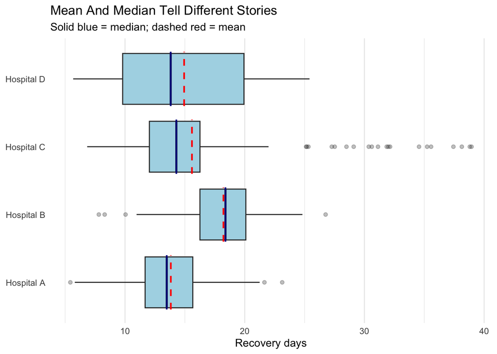

```r
ggplot(recovery_data, aes(x = recovery_days, y = hospital)) +
  geom_boxplot(outlier.alpha = 0.3, fill = "lightblue") +
  geom_segment(
    data = location_summary,
    aes(x = mean, xend = mean, y = ymin, yend = ymax),
    color = "red",
    linetype = "dashed",
    linewidth = 0.8
  ) +
  geom_segment(
    data = location_summary,
    aes(x = median, xend = median, y = ymin, yend = ymax),
    color = "darkblue",
    linewidth = 0.8
  ) +
  labs(
    title = "Mean And Median Tell Different Stories",
    subtitle = "Solid blue = median; dashed red = mean",
    x = "Recovery days",
    y = NULL
  ) +
  theme_minimal() +
  theme(panel.grid.major.y = element_blank())
```

Hospital C has long recoveries that pull the mean to the right. Hospital D has two clusters, so one center is not enough.

# Spread-Location Plot

A spread-location plot asks whether variability changes as the typical value changes.

| Data preparation step | Functions in this chunk |
| --- | --- |
| Create or change columns | `mutate()` |
| Count or summarize | `group_by()`; `ungroup()` |

```r
spread_location_data <- recovery_data |>
  group_by(hospital) |>
  mutate(
    group_median = median(recovery_days),
    spread = sqrt(abs(recovery_days - group_median))
  ) |>
  ungroup()
```

| Plot component | Code in this chunk |
| --- | --- |
| Aesthetic mappings | `x`; `y`; `color` |
| Geoms / stats | `geom_jitter()`; `stat_summary()` |
| Scales / coordinates / facets / labels | `labs()`; `theme_minimal()` |

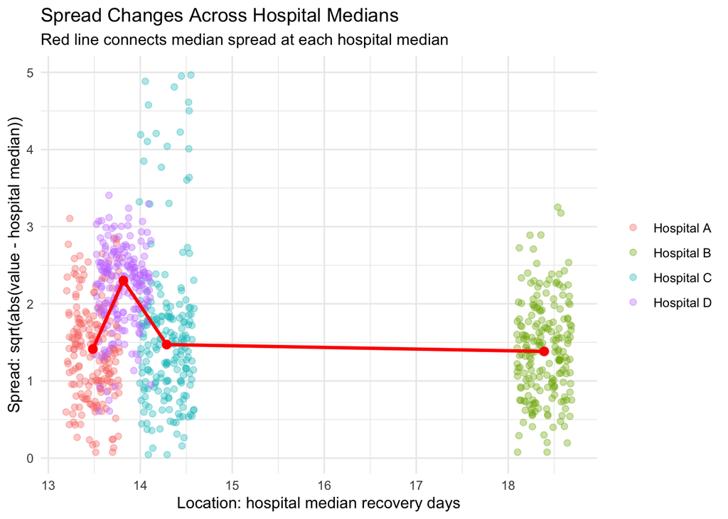

```r
ggplot(spread_location_data, aes(x = group_median, y = spread, color = hospital)) +
  geom_jitter(width = 0.3, alpha = 0.35, size = 1.8) +
  stat_summary(fun = median, geom = "line", color = "red", linewidth = 1.1, aes(group = 1)) +
  stat_summary(fun = median, geom = "point", color = "red", size = 2.5) +
  labs(
    title = "Spread Changes Across Hospital Medians",
    subtitle = "Red line connects median spread at each hospital median",
    x = "Location: hospital median recovery days",
    y = "Spread: sqrt(abs(value - hospital median))",
    color = NULL
  ) +
  theme_minimal()
```

Hospital C shows larger spread because of long recoveries. If the red line rises, variability is not constant across locations.

# Mean-Difference Plot

Mean-difference plots compare the difference between two groups against their average.

| Data preparation step | Functions in this chunk |
| --- | --- |
| Keep or remove rows | `filter()` |
| Create or change columns | `mutate()` |
| Combine data frames | `bind_rows()` |

```r
set.seed(789)

hospital_b_pairs <- recovery_data |>
  filter(hospital == "Hospital B") |>
  slice_sample(n = 150) |>
  mutate(
    hospital_a_value = sample(recovery_data$recovery_days[recovery_data$hospital == "Hospital A"], size = 150, replace = TRUE),
    mean_value = (recovery_days + hospital_a_value) / 2,
    difference = recovery_days - hospital_a_value,
    comparison = "Hospital B vs A"
  )

hospital_c_pairs <- recovery_data |>
  filter(hospital == "Hospital C") |>
  slice_sample(n = 150) |>
  mutate(
    hospital_a_value = sample(recovery_data$recovery_days[recovery_data$hospital == "Hospital A"], size = 150, replace = TRUE),
    mean_value = (recovery_days + hospital_a_value) / 2,
    difference = recovery_days - hospital_a_value,
    comparison = "Hospital C vs A"
  )

comparison_pairs <- bind_rows(hospital_b_pairs, hospital_c_pairs)
```

| Plot component | Code in this chunk |
| --- | --- |
| Aesthetic mappings | `x`; `y` |
| Geoms / stats | `geom_point()`; `geom_hline()`; `geom_smooth()` |
| Scales / coordinates / facets / labels | `facet_wrap()`; `labs()`; `theme_minimal()` |

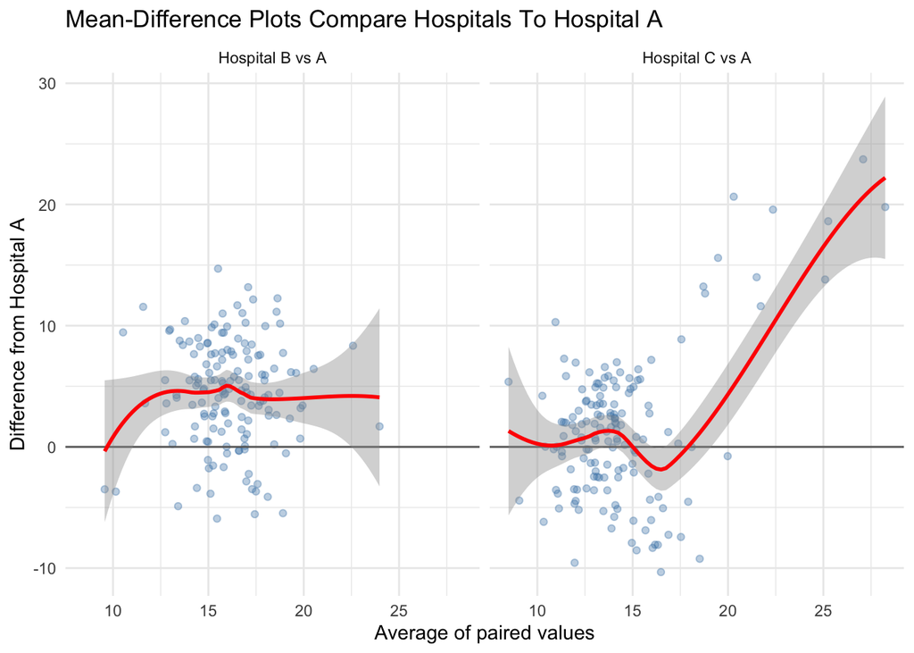

```r
ggplot(comparison_pairs, aes(x = mean_value, y = difference)) +
  geom_point(alpha = 0.35, color = "steelblue") +
  geom_hline(yintercept = 0, color = "gray40") +
  geom_smooth(method = "loess", se = TRUE, color = "red", linewidth = 1) +
  facet_wrap(vars(comparison), ncol = 2) +
  labs(
    title = "Mean-Difference Plots Compare Hospitals To Hospital A",
    x = "Average of paired values",
    y = "Difference from Hospital A"
  ) +
  theme_minimal()
```

Hospital B mostly looks like a location shift from Hospital A. Hospital C shows larger positive differences at higher averages because of long recoveries.

# Residuals From Group Means

A residual is the observed value minus a fitted value. Here, the fitted value is the hospital mean.

```r
residual_data <- recovery_data |>
  group_by(hospital) |>
  mutate(
    group_mean = mean(recovery_days),
    residual = recovery_days - group_mean
  ) |>
  ungroup()
```

| Plot component | Code in this chunk |
| --- | --- |
| Aesthetic mappings | `x`; `y` |
| Geoms / stats | `geom_boxplot()`; `geom_hline()` |
| Scales / coordinates / facets / labels | `labs()`; `theme_minimal()` |

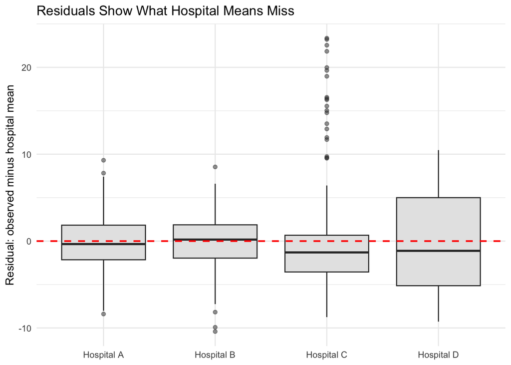

```r
ggplot(residual_data, aes(x = hospital, y = residual)) +
  geom_boxplot(fill = "gray90", outlier.alpha = 0.5) +
  geom_hline(yintercept = 0, linetype = "dashed", color = "red", linewidth = 0.8) +
  labs(
    title = "Residuals Show What Hospital Means Miss",
    x = NULL,
    y = "Residual: observed minus hospital mean"
  ) +
  theme_minimal()
```

Hospitals A and B are fairly symmetric around zero. Hospital C has large positive residuals, and Hospital D remains wide because its data are bimodal.

# R-F Spread Plot

An R-F spread plot separates between-group variation from within-group residual variation.

| Data preparation step | Functions in this chunk |
| --- | --- |
| Choose or rename columns | `select()` |
| Create or change columns | `mutate()` |
| Combine data frames | `bind_rows()` |
| Reshape data | `arrange()` |

```r
rf_data <- residual_data |>
  mutate(
    fitted = group_mean,
    grand_mean = mean(recovery_days),
    fit_minus_mean = fitted - grand_mean
  )

fitted_panel <- rf_data |>
  arrange(fitted, recovery_days) |>
  mutate(percentile_rank = (row_number() - 1) / (n() - 1)) |>
  transmute(
    panel = "Between-group variation",
    percentile_rank,
    value = fit_minus_mean,
    hospital
  )

residual_panel <- rf_data |>
  arrange(residual) |>
  mutate(percentile_rank = (row_number() - 1) / (n() - 1)) |>
  transmute(
    panel = "Within-group residual variation",
    percentile_rank,
    value = residual,
    hospital = "Residuals"
  )

rf_plot_data <- bind_rows(fitted_panel, residual_panel)
```

| Plot component | Code in this chunk |
| --- | --- |
| Aesthetic mappings | `x`; `y`; `color` |
| Geoms / stats | `geom_point()`; `geom_hline()` |
| Scales / coordinates / facets / labels | `facet_wrap()`; `scale_x_continuous()`; `labs()`; `theme_minimal()` |

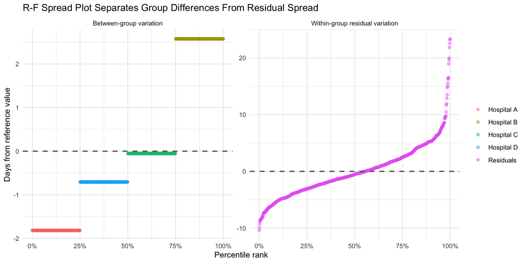

```r
ggplot(rf_plot_data, aes(x = percentile_rank, y = value, color = hospital)) +
  geom_point(alpha = 0.45, size = 1.6) +
  geom_hline(yintercept = 0, linetype = "dashed", color = "gray40", linewidth = 0.8) +
  facet_wrap(vars(panel), scales = "free_y", ncol = 2) +
  scale_x_continuous(labels = scales::label_percent()) +
  labs(
    title = "R-F Spread Plot Separates Group Differences From Residual Spread",
    x = "Percentile rank",
    y = "Days from reference value",
    color = NULL
  ) +
  theme_minimal()
```

The left panel shows how much hospital means differ from the overall mean. The right panel shows how much variation remains after subtracting hospital means.

# Takeaways

- Spread-location plots show whether variability changes with level.
- Mean-difference plots reveal whether differences depend on magnitude.
- Studying residuals and their dispersion is an effective way to understand group differences.